# FairHire AI: NYC Local Law 144 Statutory Bias Audit Report

Group 4: Risk Ready

2026-04-23

# 1 Executive Summary

This report presents the results of a **statutory bias audit** conducted on the FairHire AI automated resume screening system under **NYC Local Law 144 (2023)**, which mandates annual third-party bias audits for all automated employment decision tools (AEDTs) used in hiring within New York City.

The audit evaluates **Disparate Impact** across protected classes using the **4/5ths Rule (80% Threshold)**: any demographic group whose selection rate falls below 80% of the highest-selected group is flagged as a potential compliance violation.

Table 1: Audit Snapshot

| Metric | Value |
| --- | --- |
| Total Candidates Audited | 2,481 |
| Total Selected by AI | 707 |
| Overall Selection Rate | 28.5% |
| Gender Groups Failing 80% Rule | 0 of 3 |
| Race/Ethnicity Groups Failing 80% Rule | 1 of 5 |

# 2 Dataset Overview

The audit was conducted on resumes extracted from the FairHire AI resume dataset. Demographic attributes (gender, race/ethnicity) and AI selection outcomes were simulated to reflect realistic hiring distributions for compliance testing purposes.

Table 2: Sample Resume Records (First 10 Rows)

| resume_id | category | content | file_name |
| --- | --- | --- | --- |
| 1 | ACCOUNTANT | ACCOUNTANT Summary Financial Accountant specializing in financial planning, reporting and analysis within the Department of Defense. Highlights Account reconciliations Results-oriented Accounting oper… | 10554236.pdf |
| 2 | ACCOUNTANT | STAFF ACCOUNTANT Summary Highly analytical and detail-oriented professional; possessing extensive financial statement background in quality assurance, compliance, auditing, customer service and regula… | 10674770.pdf |
| 3 | ACCOUNTANT | ACCOUNTANT Professional Summary To obtain a position in a fast-paced business office environment, demanding a strong organizational, technical, and interpersonal position utilizing my skills and attri… | 11163645.pdf |
| 4 | ACCOUNTANT | SENIOR ACCOUNTANT Experience Company Name June 2011 to Current Senior Accountant City , State Prepare quarterly and annual financial statements for 17 multi-family communities for distribution to inve… | 11759079.pdf |
| 5 | ACCOUNTANT | SENIOR ACCOUNTANT Professional Summary Senior accountant who completes accounting activities with accuracy and speed with extensive experience in full life cycle of general ledger accounting Skills Ad… | 12065211.pdf |
| 6 | ACCOUNTANT | INVESTMENT ACCOUNTANT Career Focus Accomplished and results oriented Investment professional with strong leadership and interpersonal skills who adds energy and value to an organization’s quest for ex… | 12202337.pdf |
| 7 | ACCOUNTANT | ACCOUNTANT Summary To pursue excellence in the dynamic business world by obtaining a placement allowing me to perform in an environment where honesty, sincerity & a positive attitude would be valued. … | 12338274.pdf |
| 8 | ACCOUNTANT | ACCOUNTANT Summary To utilize my customer relations and management background to obtain a position with a company that places importance on efficiency and success. Employ natural leadership and interp… | 12442909.pdf |
| 9 | ACCOUNTANT | ACCOUNTANT II Accomplishments Military Training Certificate, 2005; PNC Conversation: Deep Dive into Savings and Investment training 2012; Operational and Soundness Training 2013; Employee of the month… | 12780508.pdf |
| 10 | ACCOUNTANT | LEAD ACCOUNTANT Highlights QuickBooks, Peachtree, In-house Accounting Systems and Financial Reporting, MAS 90, FAR, WAWF, Great Plains, Integration Manager, FRx reporting. Hyperion Workspace, Planning… | 12802330.pdf |

# 3 Gender Bias Audit

## Selection Rate Results

Table 3: Gender Selection Rates & Impact Ratios

| Gender | Total Candidates | Selected | Selection Rate | Impact Ratio | LL144 Status |
| --- | --- | --- | --- | --- | --- |
| Non-Binary | 89 | 26 | 29.2% | 1.0000 | PASS |
| Female | 1191 | 343 | 28.8% | 0.9858 | PASS |
| Male | 1201 | 338 | 28.1% | 0.9634 | PASS |

## Impact Ratio Chart

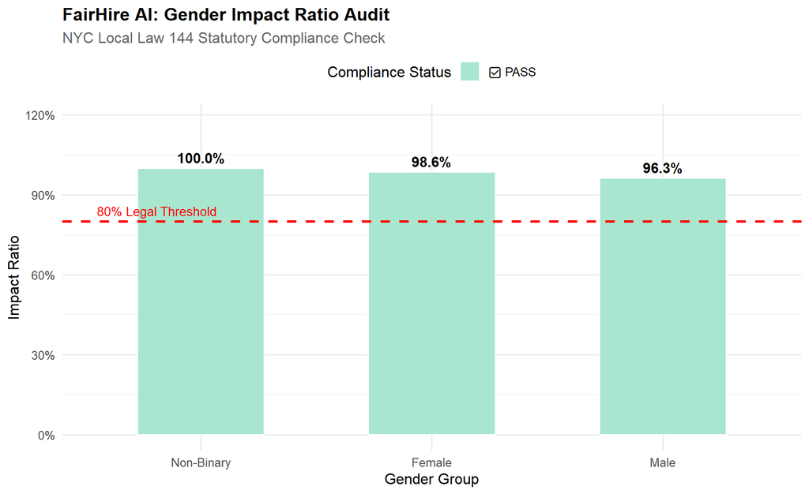

Figure 1: Gender Impact Ratios — red dashed line marks the 80% legal threshold

# 4 Race & Ethnicity Bias Audit

## Selection Rate Results

Table 4: Race/Ethnicity Selection Rates & Impact Ratios

| Race / Ethnicity | Total Candidates | Selected | Selection Rate | Impact Ratio | LL144 Status |
| --- | --- | --- | --- | --- | --- |
| Other | 509 | 166 | 32.6% | 1.0000 | PASS |
| Asian | 518 | 155 | 29.9% | 0.9175 | PASS |
| Hispanic | 465 | 127 | 27.3% | 0.8375 | PASS |
| White | 491 | 130 | 26.5% | 0.8118 | PASS |
| Black | 498 | 129 | 25.9% | 0.7943 | FAIL (Potential Bias) |

## Impact Ratio Chart

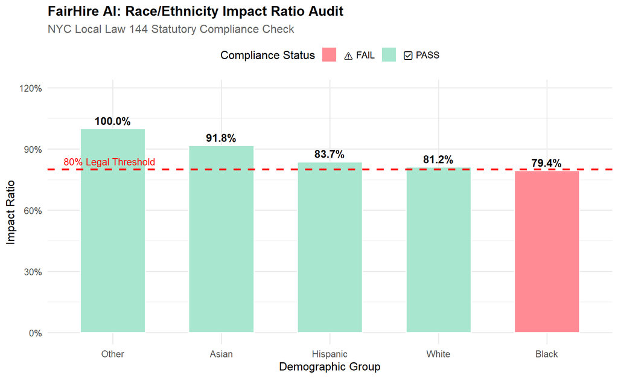

Figure 2: Race/Ethnicity Impact Ratios — red dashed line marks the 80% legal threshold

# 5 Bias Mitigation: Reweighing

When a group fails the 80% rule, NYC LL144 requires the employer to implement a **bias mitigation strategy**. This section applies the **Reweighing** pre-processing technique — the same approach used in IBM’s AIF360 toolkit — which adjusts candidate weights so underrepresented groups receive equitable consideration without discarding any applications.

## Before vs. After Comparison Table

Table 5: Reweighing Debiasing — Before vs. After

| Model Stage | Race / Ethnicity | Selected | Selection Rate | Impact Ratio | LL144 Status |
| --- | --- | --- | --- | --- | --- |
| **Before Debiasing** |  |  |  |  |  |
| Before Debiasing | Other | 166 | 32.6% | 1.0000 | PASS |
| Before Debiasing | Asian | 155 | 29.9% | 0.9175 | PASS |
| Before Debiasing | Hispanic | 127 | 27.3% | 0.8375 | PASS |
| Before Debiasing | White | 130 | 26.5% | 0.8118 | PASS |
| Before Debiasing | Black | 129 | 25.9% | 0.7943 | FAIL (Potential Bias) |
| **After Debiasing** |  |  |  |  |  |
| After Debiasing | Asian | 149 | 28.8% | 1.0000 | PASS |
| After Debiasing | Hispanic | 127 | 27.3% | 0.9495 | PASS |
| After Debiasing | Other | 139 | 27.3% | 0.9494 | PASS |
| After Debiasing | White | 130 | 26.5% | 0.9205 | PASS |
| After Debiasing | Black | 129 | 25.9% | 0.9005 | PASS |

## Before vs. After Chart

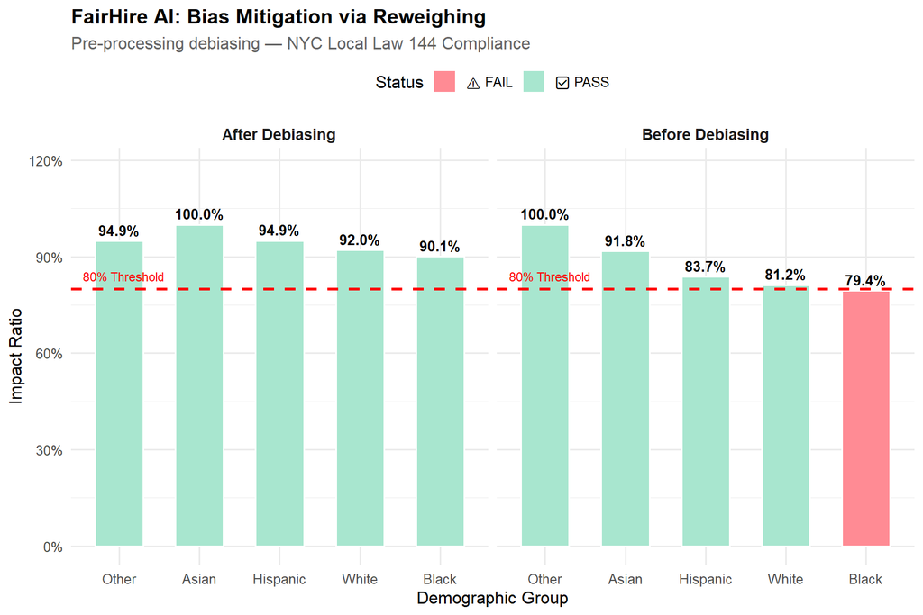

Figure 3: Impact Ratios before and after Reweighing bias mitigation

# 6 Compliance Summary & Recommendations

Table 6: Full Compliance Summary — All Protected Classes

| Protected Class | Group | Selection Rate | Impact Ratio | LL144 Status |
| --- | --- | --- | --- | --- |
| Gender | Non-Binary | 29.2% | 1.0000 | PASS |
| Gender | Female | 28.8% | 0.9858 | PASS |
| Gender | Male | 28.1% | 0.9634 | PASS |
| Race / Ethnicity | Other | 32.6% | 1.0000 | PASS |
| Race / Ethnicity | Asian | 29.9% | 0.9175 | PASS |
| Race / Ethnicity | Hispanic | 27.3% | 0.8375 | PASS |
| Race / Ethnicity | White | 26.5% | 0.8118 | PASS |
| Race / Ethnicity | Black | 25.9% | 0.7943 | FAIL (Potential Bias) |